# LSTAT2340 - Analyse de données métagénomique ciblée (16s) : illustration avec données illumina

Jerome Ambroise - UCL - IREC - CTMA

März 15, 2021,11:59

Dans ce document, nous allons réaliser l’analyses de données métagénomique provenant du tube digestif de 18 pucerons appartenant à 3 espèces (6 pucerons par espèce). Nous allons réaliser des graphiques qui illustrent l’abondance des bactéries dans les pucerons. Nous allons également comparere les diversités alpha et béta entre les éhantillons. Finalement, nous allons voir si les communautés bactériennes sont plutôt influencées par l’espèce de puceron ou plutôt par l’altitude à laquelle l’échantillon a été récolté.

Attention !!:

Dans ce document nous utilisons la notion de OTU. Depuis quelques années, les chercheurs de nombreux domaines préfèrent utiliser la notion de ASV (Amplicon Sequencing Variant). Cependant, pour des raisons pédagogiques, nous allons utiliser la notions de OTU dans le document ci-dessous. Pour plus d’informations, voir par exemple: https://fr.wikipedia.org/wiki/Variant_de_s%C3%A9quence_d%27amplicon

# 1 Chargement des package

```r
suppressMessages(library(phyloseq))
suppressMessages(library(Biostrings))
suppressMessages(library(phangorn))
suppressMessages(library(GUniFrac))
suppressMessages(library(ade4))
suppressMessages(library(muscle))
```

# 2 Importation des données de comptage et pre-traitement

```r
table <- read.table('1-data-in/otu.Table.txt',sep='\t')
print(table)
```

```
##          Dn.1   Dn.2   Dn.3  Dn.4   Dn.5   Dn.6  Rp.1  Rp.2  Rp.3  Rp.4  Rp.5
## OTU_001  1886   2421   2012  1030   1614   2192 33704 64290 59669 62730 63010
## OTU_002   143    187    180    93    173    199   139   141   131   144   183
## OTU_003     1      2      5     1      2      3     2     3     4     2     2
## OTU_004  1904   1396   2821  1827   1682   3008  3013  6501  6736  7747  8243
## OTU_005 86995 124514 107618 58430 112857 113258 38583 77184 77722 84292 87070
## OTU_006     1      0      0     0      0      0     0     0     0     1     1
## OTU_007     0      0      1     0      0      2     1     7     1     4     0
## OTU_008    10      0      0     0      0      0     0     0     0     0     0
## OTU_009     0      0      0     0      0      0     0     0     0     3     0
## OTU_010     5      2      1     0      5      0     4     0     2     1     0
## OTU_011     0      3      4     1      2      1     0     5     3     0     1
## OTU_012     3     13      8     0      2      1     1     6     5    11     5
## OTU_013     1      7      4     1      1     10     3     5     3     4     4
## OTU_014    10      0      0     5      0      0     0     8     0     0     0
## OTU_015     0     10      0     0     10      1     0     0     0     0     0
## OTU_016     0      6      0     1      0     10     0     1     0     2     0
## OTU_017     8      8      7     0      1      2     1    83     3    10     6
##          Rp.6  Rm.1  Rm.2  Rm.3  Rm.4  Rm.5  Rm.6
## OTU_001 63610    29    23    21    28     4     8
## OTU_002   146 93081 70452 76172 72385    46    49
## OTU_003     0     1     3     0     0 64937 63848
## OTU_004  6530   493   367   434   396    68    50
## OTU_005 74298    29    32    27    21    11    15
## OTU_006     0     2     0     0     1 18219 11187
## OTU_007     0  6211 10447 11381     7     0     2
## OTU_008     0     1     1     0     0     0     0
## OTU_009     0     0     0     0  7487     0     0
## OTU_010     0    10     0     8     0     6     0
## OTU_011     3     0     0     0     0     1     0
## OTU_012     2     3     5     0     0     1     2
## OTU_013     2     3     0     1     0     0     0
## OTU_014     0     0     0     0     0     0     0
## OTU_015     0     0     0     0     0     0     0
## OTU_016     0     0     0     0     0     0     0
## OTU_017     1     0     1     1     0     1     0
```

```r
apply(table,2,sum)
```

```
##   Dn.1   Dn.2   Dn.3   Dn.4   Dn.5   Dn.6   Rp.1   Rp.2   Rp.3   Rp.4   Rp.5
##  90967 128569 112661  61389 116349 118687  75451 148234 144279 154951 158525
##   Rp.6   Rm.1   Rm.2   Rm.3   Rm.4   Rm.5   Rm.6
## 144592  99863  81331  88045  80325  83294  75161
```

Dans ce tableau, on observe les 18 échantillons/individus (pucerons) et les 17 variables (OTU n°1 … OTU n°17) (1 OTU correspond à un groupe de bactérie très homogène). Les individus correspondent aux colonnes alors que les variables sont les lignes. En génomique, cette organisation des données est largement utilisée étant donné que le nombre de variables est générallement beaucoup plus grand que le nombre d’observations.

On remarque que le nombre total de bactéries différe en fonction du puceron (90967 pour le premier pucerons versus 128569 pour le deuxième puceron). Nous allons appliquer une étape de raréfaction afin de partir sur un nombre identique (50.000) de bactéries par pucerons et de rendre les données comparables entre elles.

```r
OTU <- otu_table(table,taxa_are_rows = T)
myphyloseq <- phyloseq(OTU)
myphyloseq <- rarefy_even_depth(myphyloseq, sample.size = 50000, replace = F)
```

```
## You set `rngseed` to FALSE. Make sure you've set & recorded
##  the random seed of your session for reproducibility.
## See `?set.seed`
```

```
## ...
```

```r
table.rrf <- data.frame(otu_table(myphyloseq))
apply(table.rrf,2,sum)
```

```
##  Dn.1  Dn.2  Dn.3  Dn.4  Dn.5  Dn.6  Rp.1  Rp.2  Rp.3  Rp.4  Rp.5  Rp.6  Rm.1
## 50000 50000 50000 50000 50000 50000 50000 50000 50000 50000 50000 50000 50000
##  Rm.2  Rm.3  Rm.4  Rm.5  Rm.6
## 50000 50000 50000 50000 50000
```

```r
OTU <- otu_table(table.rrf,taxa_are_rows= T)
```

# 3 Importation des données taxonomiques

```r
otus <- readDNAStringSet("1-data-in/otus.fasta", format = "fasta")
print(otus)
```

```
## DNAStringSet object of length 17:
##      width seq                                              names
##  [1]   465 CCTACGGGGGGCTGCAGTGGGGA...AGGATTAGATACCCCGGTAGTC OTU_001
##  [2]   465 CCTACGGGGGGCTGCAGTGGGGA...AGGATTAGATACCCCGGTAGTC OTU_002
##  [3]   465 CCTACGGGTGGCTGCAGTGGGGA...AGGATTAGATACCCCGGTAGTC OTU_003
##  [4]   465 CCTACGGGTGGCAGCAGTGGGGA...AGGATTAGATACCCGTGTAGTC OTU_004
##  [5]   464 CCTACGGGTGGCAGCAGTGGGGA...CAGGATTAGATACCCGAGTGTC OTU_005
##  ...   ... ...
## [13]   465 CCTACGGGGGGCTGCAGTGGGGA...AGGATTAGATACCCGGGTAGTC OTU_013
## [14]   466 CCTACGGGGGGCTGCAGTGGGGA...AGGATTAGATACCCGTGTAGTC OTU_014
## [15]   465 CCTACGGGGGGCTGCAGTGGGGA...AGGATTAGATACCCGTGTAGTC OTU_015
## [16]   465 CCTACGGGTGGCAGCAGTGGGGA...AGGATTAGATACCCGTGTAGTC OTU_016
## [17]   465 CCTACGGGTGGCAGCAGTAGGGA...AGGATTAGATACCCCTGTAGTC OTU_017
```

```r
taxonomy <- read.table('1-data-in/taxonomy.txt',sep='\t')
print(taxonomy)
```

```
##         kingdom         phylum               class             order
## OTU_001 acteria Proteobacteria Gammaproteobacteria Enterobacteriales
## OTU_002 acteria Proteobacteria Gammaproteobacteria Enterobacteriales
## OTU_003 acteria Proteobacteria Gammaproteobacteria Enterobacteriales
## OTU_004 acteria Proteobacteria Gammaproteobacteria Enterobacteriales
## OTU_005 acteria Proteobacteria Gammaproteobacteria Enterobacteriales
## OTU_006 acteria Proteobacteria Gammaproteobacteria Enterobacteriales
## OTU_007 acteria Proteobacteria Gammaproteobacteria Enterobacteriales
## OTU_008 acteria Proteobacteria Gammaproteobacteria Enterobacteriales
## OTU_009 acteria Proteobacteria Gammaproteobacteria Enterobacteriales
## OTU_010 acteria Proteobacteria Gammaproteobacteria   Pseudomonadales
## OTU_011 acteria Proteobacteria Gammaproteobacteria   Pseudomonadales
## OTU_012 acteria Proteobacteria Gammaproteobacteria   Pseudomonadales
## OTU_013 acteria Proteobacteria Gammaproteobacteria   Pseudomonadales
## OTU_014 acteria Proteobacteria Gammaproteobacteria   Pseudomonadales
## OTU_015 acteria Proteobacteria Gammaproteobacteria Enterobacteriales
## OTU_016 acteria Proteobacteria Gammaproteobacteria Enterobacteriales
## OTU_017 acteria     Firmicutes             Bacilli        Bacillales
##                    familly          genus
## OTU_001 Enterobacteriaceae       Buchnera
## OTU_002 Enterobacteriaceae       Buchnera
## OTU_003 Enterobacteriaceae       Buchnera
## OTU_004 Enterobacteriaceae       Buchnera
## OTU_005 Enterobacteriaceae       Buchnera
## OTU_006 Enterobacteriaceae       Serratia
## OTU_007 Enterobacteriaceae       Regiella
## OTU_008 Enterobacteriaceae       Regiella
## OTU_009 Enterobacteriaceae   Hamiltonella
## OTU_010   Pseudomonadaceae    Pseudomonas
## OTU_011   Pseudomonadaceae    Pseudomonas
## OTU_012   Pseudomonadaceae    Pseudomonas
## OTU_013   Pseudomonadaceae    Pseudomonas
## OTU_014      Moraxellaceae  Acinetobacter
## OTU_015 Enterobacteriaceae        Pantoea
## OTU_016 Enterobacteriaceae        Erwinia
## OTU_017  Staphylococcaceae Staphylococcus
```

```r
taxtable <- tax_table(as.matrix(taxonomy))
```

# 4 Importation des données phénotypiques

Nous importons également les données de caractérisation des pucerons.

```r
phenotypic <- read.csv('1-data-in/phenotypic.csv')
rownames(phenotypic) <- colnames(table.rrf)
sampledata <- sample_data(phenotypic)
```

# 5 Fusion de toutes les informations dans un objet de type phyloseq

```r
myphyloseq <- phyloseq(OTU,taxtable,sampledata)
print(myphyloseq)
```

```
## phyloseq-class experiment-level object
## otu_table()   OTU Table:         [ 17 taxa and 18 samples ]
## sample_data() Sample Data:       [ 18 samples by 2 sample variables ]
## tax_table()   Taxonomy Table:    [ 17 taxa by 6 taxonomic ranks ]
```

# 6 Représentations graphiques des abondances de bactéries dans les pucerons

Nous allons réaliser deux représentations des données qui sont largement utilisées dans la littérature.

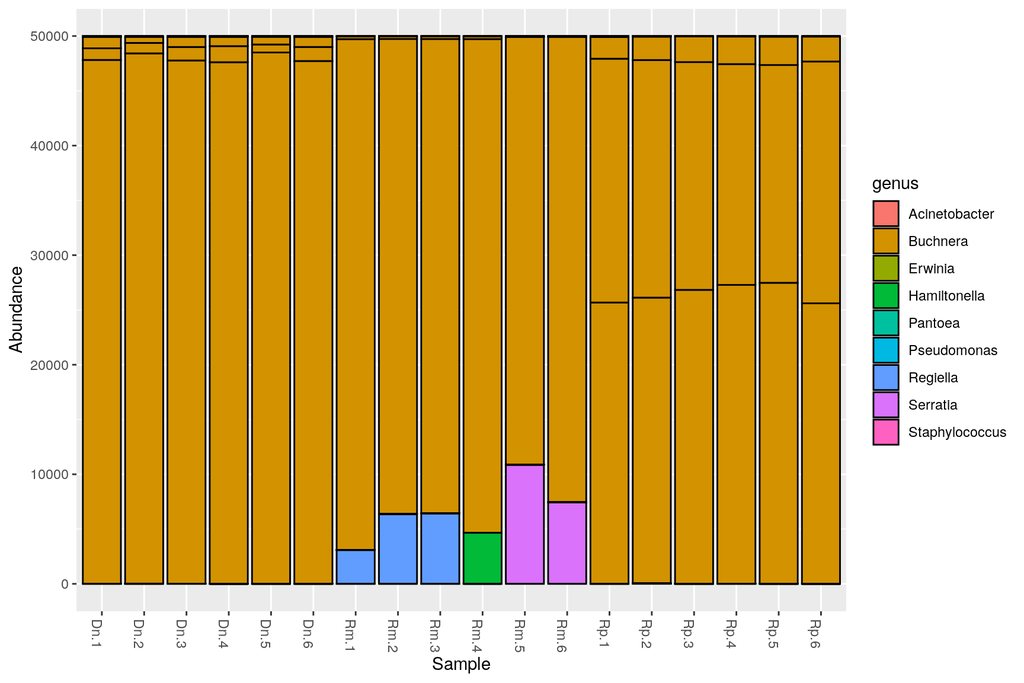

```r
plot_bar(myphyloseq,fill='genus')
```

Dans ce barplot, on observe facilement que les tubes digestifs de deux espèces de pucerons sont peuplés par une large majorité d’une seule espèce bactérienne (appelée Buchnéra). Pour la troisième espèce de puceron, plusieurs autres epsèces de bactéries sont également présentes en grande quantité (Regiella, Seratia, Hamiltonella).

Ces informations sont également visibles dans le ‘Heatmap’ ci-dessous:

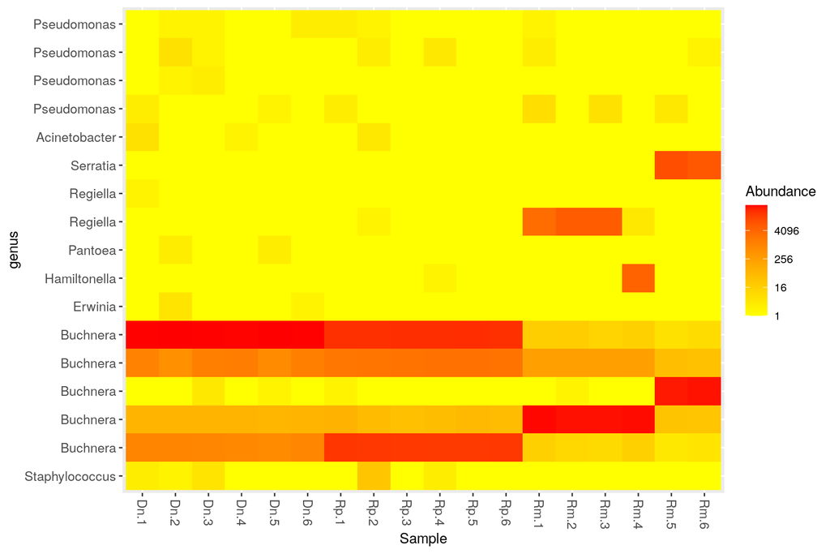

```r
plot_heatmap(myphyloseq,taxa.label='genus',taxa.order='genus',sample.order=colnames(table.rrf),low='yellow',high='red',na.value = 'yellow')
```

# 7 Analyse de la diversité Alpha

La diversité alpha est une mesure de la diversité intra-échantillon. Plusieurs indices sont utilisés dans la littérature pour la caractériser. Les plus populaires sont le nombre d’OTUs observés, l’indice de Shannon et l’indice de Simpson.

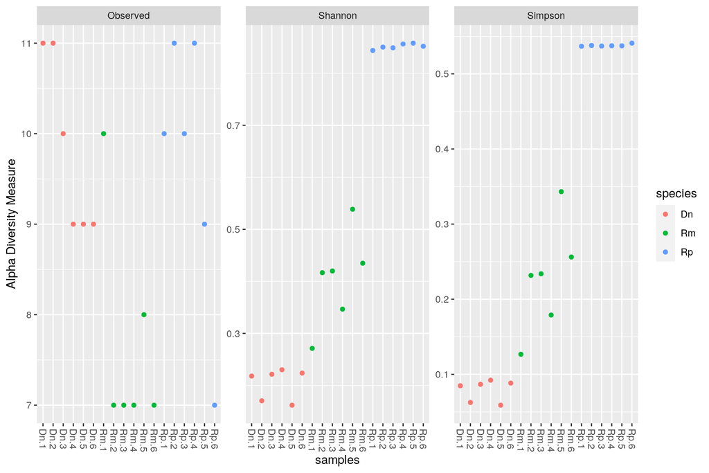

```r
plot_richness(myphyloseq,measures=c("Observed", "Shannon", "Simpson"),color='species')
```

# 8 Analyse de la diversité Béta

La diversité beta est une mesure de la diversité inter-échantillon. Elle est caractérisée par une matrice de distance entre chaque paire d’échantillons. Dans ce document, nous allons calculer cette distance avec la métrique Unifrac généralisée (implémentée dans le package GUnifrac).

Dans un premier temps, nous devons calculer un arbre phylogénétique sur bases des séquences des 17 OTUs

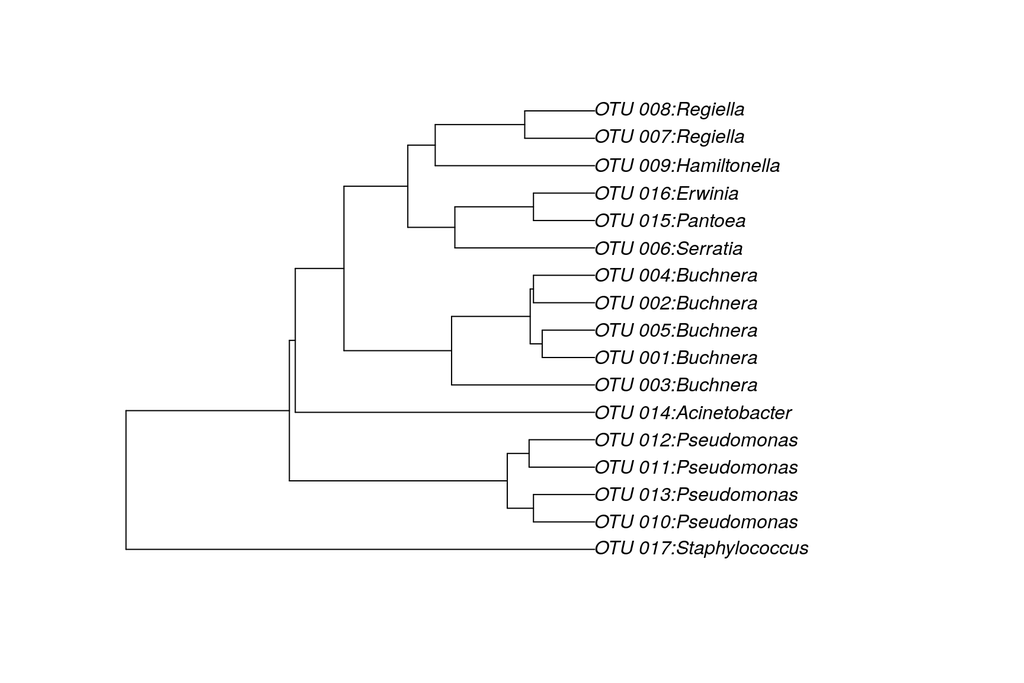

```r
names(otus) <- paste(names(otus),taxonomy$genus,sep=':')
row.names(table.rrf) <- names(otus)
align.muscle <- muscle::muscle(otus,quiet=T)
dist1 <- stringDist(as(align.muscle,"DNAStringSet"), method="hamming")
mytree1 <- upgma(dist1)
plot(mytree1)
```

Nous pouvons alors calculer la matrice de distance.

```r
unifracs <- GUniFrac(t(table.rrf), mytree1)$unifracs
d5 <- unifracs[, , "d_0.5"]
```

Il est possible de tester si les distances inter-échantillons sont plutôt influencées par l’espèce de puceron ou plutôt par l’altitude à laquelle l’échantillon a été prélevé.

```r
myadonis <- adonis(as.dist(d5) ~ species+altitude,data=phenotypic)
myadonis
```

```
##
## Call:
## adonis(formula = as.dist(d5) ~ species + altitude, data = phenotypic)
##
## Permutation: free
## Number of permutations: 999
##
## Terms added sequentially (first to last)
##
##           Df SumsOfSqs  MeanSqs F.Model      R2 Pr(>F)
## species    2   0.37718 0.188588  9.6501 0.54397  0.001 ***
## altitude   1   0.04261 0.042608  2.1803 0.06145  0.137
## Residuals 14   0.27360 0.019543         0.39458
## Total     17   0.69338                  1.00000
## ---
## Signif. codes:  0 '***' 0.001 '**' 0.01 '*' 0.05 '.' 0.1 ' ' 1
```

Il est également possible de visualiser cette matrice de distance avec une analyse PCoA (Principal Coordinates analysis)

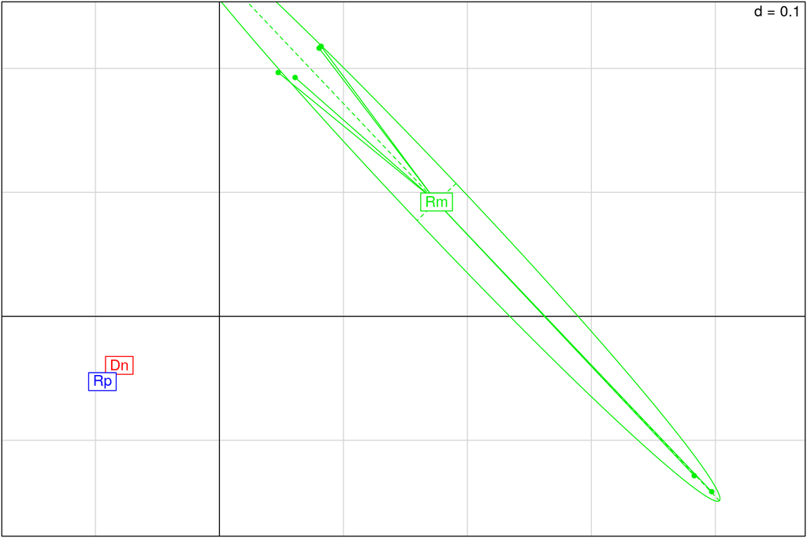

```r
s.class(cmdscale(d5, k=2), fac = factor(phenotypic$species),col=c('red','green2','blue'))
```

# 9 Analyse de l’abondance différentielle

Cette analyse dépasse un peu le cadre de ce cours. Cependant, on peut appliquer des méthodes similaires à celles aplliquées en RNA-SEQ et discutées ensemble lors du module sur la transcriptomique (voir cours du 22/02/2021).

# 10 Conclusion générale et valeur ajoutée du statisticien

Il s’agit d’un domaine dans lequel les méthodes évoluent encore.

En tant que statisticien, on peut se poser certaines question par rapport à l’utilisation de modèle mixtes dans des études où plusieurs souris sont élevées dans une même cage (et ont donc tendance à avoir un microbiote qui se ressemble). Il existe très peu de littérature à ce sujet.

Dans le cas du sc-RNA-SEQ, la question de l’utilisation de modèle mixtes se pose également car de nombreuses cellules proviennent d’un même patients et ne devraient donc sans doute pas être considérées comme ‘indépendantes’.